# Gastos de Parlamentares em 2016

# Introdução

Os dados coletados abaixo foram coletados do site de transparência da câmara dos deputados. Esses dados contém todos os gastos de nossos deputados em 2016 usando a sua cota para exercício da atividade parlamentar

## Tratando dos Dados

```r
ler_gastos <- function(arquivo = "../datasets/gastos.csv") {
  #' Lê um csv criado a partir dos dados de gastos dos deputados da
  #' Câmara e seta os tipos de colunas mais convenientemente.
  require("readr")
  require("dplyr", warn.conflicts = FALSE)

  gastos = read_csv(arquivo, col_types = list(datEmissao = col_datetime()))
  gastos = gastos %>%
    mutate_each(funs(as.factor), sgPartido, sgUF, txNomeParlamentar, indTipoDocumento, numMes)

  levels(gastos$numMes) =
    list("Janeiro"="1", "Fevereiro"="2", "Março"="3", "Abril"="4", "Maio"="5", "Junho"="6", "Julho"="7")

  return(gastos)
}
```

## Carregando os Dados

```r
parlamentares = ler_gastos()

parlamentares = parlamentares %>%
  select(txNomeParlamentar, sgUF, sgPartido, txtDescricao, vlrDocumento, txtMes = numMes)
```

# Questões

| Descricao | Gastos |
| --- | --- |
| ASSINATURA DE PUBLICAÇÕES | 238637.44 |
| COMBUSTÍVEIS E LUBRIFICANTES. | 8805365.56 |
| CONSULTORIAS, PESQUISAS E TRABALHOS TÉCNICOS. | 9770665.31 |
| DIVULGAÇÃO DA ATIVIDADE PARLAMENTAR. | 21732111.24 |
| EMISSÃO BILHETE AÉREO | 14368471.81 |
| FORNECIMENTO DE ALIMENTAÇÃO DO PARLAMENTAR | 873431.20 |
| HOSPEDAGEM ,EXCETO DO PARLAMENTAR NO DISTRITO FEDERAL. | 851350.33 |
| LOCAÇÃO OU FRETAMENTO DE AERONAVES | 1138794.20 |
| LOCAÇÃO OU FRETAMENTO DE EMBARCAÇÕES | 7508.36 |
| LOCAÇÃO OU FRETAMENTO DE VEÍCULOS AUTOMOTORES | 11503802.86 |
| MANUTENÇÃO DE ESCRITÓRIO DE APOIO À ATIVIDADE PARLAMENTAR | 11132307.62 |
| PARTICIPAÇÃO EM CURSO, PALESTRA OU EVENTO SIMILAR | 163486.93 |
| PASSAGENS AÉREAS | 959037.74 |
| PASSAGENS TERRESTRES, MARÍTIMAS OU FLUVIAIS | 44908.49 |
| SERVIÇO DE SEGURANÇA PRESTADO POR EMPRESA ESPECIALIZADA. | 742202.27 |
| SERVIÇO DE TÁXI, PEDÁGIO E ESTACIONAMENTO | 394983.58 |
| SERVIÇOS POSTAIS | 1713960.60 |
| TELEFONIA | 5115316.91 |

- Logo, a distribuição dos dados dessas variáveis em termos de centralidade, extremos, concentração e simetria é dada pelos dados abaixo:

```
##     Min.  1st Qu.   Median     Mean  3rd Qu.     Max.
##     7508   481800  1049000  4975000  9529000 21730000
```

2. Há algo surpreendente ou estranho nos dados?
- R: Sim, os valores de documentos (gastos) negativos dificultando a analise dos dados.
3. Como você sugere que um analista de dados lide com a parte surpreendente/estranha?
- R: Eu aconselharia sua analise dos dados agrupados por tipo de despesa (como foi feito da questão 2) ou por parlamentar.
2. Responda:
1. Em que tipo de despesas nossos parlamentares gastam mais recursos de sua cota?

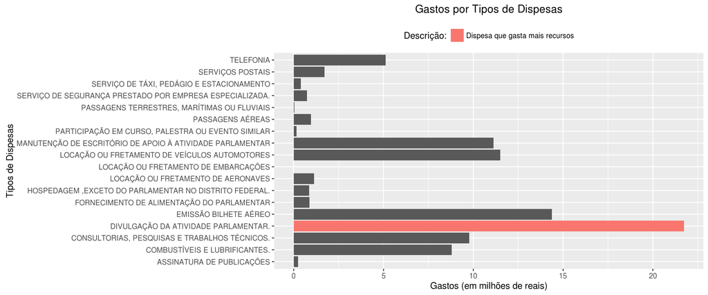

2. Quais tipos de despesas têm despesas que mais variam, que têm valores mais desiguais?

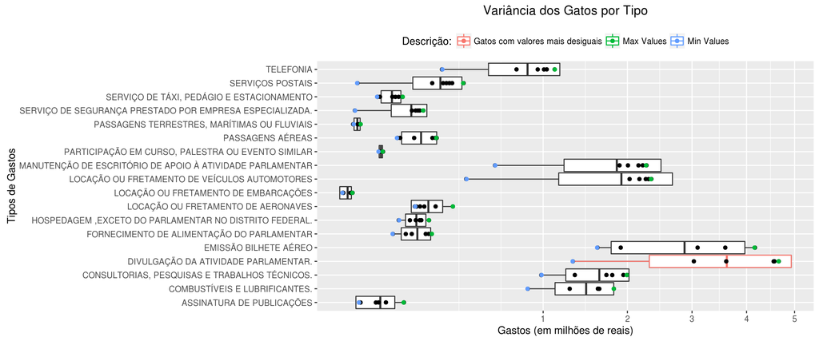